# Starbucks Capstone Challenge

## Project Definition

### Project Overview

Promotions play an important role in driving sales. Having a discount when purchasing means saving more money for the customers. However, to those who do not make purchases based on promotions, getting excessive offers means stuffed mailbox and extra attention on less worthy things. Certain kinds of people respond to certain offers in different ways. Some people might respond to the offers negatively. Offers should not be sent to the population as a whole, but at an individual personalized level.

This data set contains simulated data that mimics customer behavior on the Starbucks rewards mobile app. Once every few days, Starbucks sends out an offer to users of the mobile app. An offer can be merely an advertisement for a drink or an actual offer such as a discount or BOGO (buy one get one free). Some users might not receive any offer during certain week, and not all users receive the same offer. This data set is a simplified version of the real Starbucks app because the underlying simulator only has one product whereas Starbucks actually sells dozens of products.

Every offer has a validity period before the offer expires. As an example, a BOGO offer might be valid for only 5 days. Informational offers have a validity period even though these ads are merely providing information about a product; for example, if an informational offer has 7 days of validity, you can assume the customer is feeling the influence of the offer for 7 days after receiving the advertisement.

There will be transactional data showing user purchases made on the app including the timestamp of purchase and the amount of money spent on a purchase. This transactional data also has a record for each offer that a user receives as well as a record for when a user actually views the offer. There are also records for when a user completes an offer.

Here, I will combine transaction, demographic and offer data to determine which demographic groups respond best to which offer type.

#### Data Sets

The data is contained in three files:

- portfolio.json - containing offer ids and meta data about each offer (duration, type, etc.)
- profile.json - demographic data for each customer
- transcript.json - records for transactions, offers received, offers viewed, and offers completed

Here is the schema and explanation of each variable in the files:

**portfolio.json**

- id (string) - offer id
- offer_type (string) - type of offer ie BOGO, discount, informational
- difficulty (int) - minimum required spend to complete an offer
- reward (int) - reward given for completing an offer
- duration (int) - time for offer to be open, in days
- channels (list of strings)

**profile.json**

- age (int) - age of the customer
- became_member_on (int) - date when customer created an app account
- gender (str) - gender of the customer (note some entries contain 'O' for other rather than M or F)
- id (str) - customer id
- income (float) - customer's income

**transcript.json**

- event (str) - record description (ie transaction, offer received, offer viewed, etc.)
- person (str) - customer id
- time (int) - time in hours since start of test. The data begins at time t=0
- value - (dict of strings) - either an offer id or transaction amount depending on the record

#### Customer Sernario

1. A user could receive a discount offer buy 10 dollars get 2 off on Monday. The offer is valid for 10 days from receipt. If the customer accumulates at least 10 dollars in purchases during the validity period, the customer completes the offer.
2. Customers do not opt into the offers that they receive; in other words, a user can receive an offer, never actually view the offer, and still complete the offer. For example, a user might receive the "buy 10 dollars get 2 dollars off offer", but the user never opens the offer during the 10 day validity period. The customer spends 15 dollars during those ten days. There will be an offer completion record in the data set; however, the customer was not influenced by the offer because the customer never viewed the offer.
3. Some demographic groups will make purchases even if they don't receive an offer. From a business perspective, if a customer is going to make a 10 dollar purchase without an offer anyway, you wouldn't want to send a buy 10 dollars get 2 dollars off offer. I will try to assess what a certain demographic group will buy when not receiving any offers.

### Problem Statement

1. I will combine the offer portfolio, customer profile, and transaction data. One DataFrame will be generated representing the total amount of transaction with an offer's attributes and customer demographic data. Data visulisation will be performed on the data
2. Clustering was used to help group the members based on their purchasing behavior, which should further our understanding.
3. The combined data will be split into training and testing sets. Regression will be used to predict the transaction amount based on demographic. I will assess the R-square and mean-square-error.Parameters will be optimized for the regression models. The performance of each regression model will be compared.

**Here is the general structure of the project:**

1. *Analysis*: Data exploration and visualization
2. *Clustering*:
   1. Density-based clustering

      ```
       * On offer attributes and demographic data combined
       * On offer attributes only, but later find demographic characters based on the clusters
      ```

   2. k-means clustering

      ```
       * On offer attributes only.
      ```

   3. Agglomerative Clustering

      ```
       * On offer attributes only.
      ```

3. *Regression*:
   1. K - Neighbors Regression
   2. Extra Tree Regression
4. *Discussion and Conclusion*

### Metrics

Regression models will be evaluated with **mean squared error** and **R-squared** on the testing set.

- Mean square error is an estimator (of a procedure for estimating an unobserved quantity) measures the average of the squares of the errors — that is, the average squared difference between the estimated values and what is estimated. We want the MSE to be as close to 0 as possible.
- R-squared measures the strength of the relationship between your model and the dependent variable on a convenient 0 – 100% scale. A 1 represents a model that explains all of the variation in the response variable around its mean. Here we want the R-squared to be as close to 1 as possible.

```python
#import necessary libraries and import data
import progressbar

import matplotlib.pyplot as plt

import pandas as pd
import numpy as np
import math
import json
%matplotlib inline

# read in the json files
portfolio = pd.read_json('data/portfolio.json', orient='records', lines=True)
profile = pd.read_json('data/profile.json', orient='records', lines=True)
transcript = pd.read_json('data/transcript.json', orient='records', lines=True)
```

```python
import starbucks
```

```python
import imp
imp.reload(starbucks)
```

```
Modules imported successfully.
```

```
<module 'starbucks' from 'E:\\Data_Science_Coursework\\Udacity_Data_Science_Nanodegree\\Capstone\\starbucks.py'>
```

## Analysis

### Portfolio Dataset Exploration and Visualization

The `starbucks_data_cleaning` function conducts the follwing actions:

1. Separates the 'channel' column into individual columns. If certain channel is used, the number will be 1. Otherwise, 0.
2. Set offer id as index
3. Separate the offer types into separate columns
4. Add a new row with id 'wo_offer'. Add a new attribute column as 'no_offer'. Row 'no_offer' has all 0 except at 'no_offer' attribute.

```python
portfolio = starbucks.portfolio_data_cleaning(portfolio = portfolio)
portfolio
```

|  | reward | difficulty | duration | social | email | mobile | web | val | bogo | discount | informational | no_offer |
| --- | --- | --- | --- | --- | --- | --- | --- | --- | --- | --- | --- | --- |
| ae264e3637204a6fb9bb56bc8210ddfd | 10 | 10 | 7 | 1.0 | 1.0 | 1.0 | 0.0 | 1 | 1 | 0 | 0 | 0 |
| 4d5c57ea9a6940dd891ad53e9dbe8da0 | 10 | 10 | 5 | 1.0 | 1.0 | 1.0 | 1.0 | 1 | 1 | 0 | 0 | 0 |
| 3f207df678b143eea3cee63160fa8bed | 0 | 0 | 4 | 0.0 | 1.0 | 1.0 | 1.0 | 1 | 0 | 0 | 1 | 0 |
| 9b98b8c7a33c4b65b9aebfe6a799e6d9 | 5 | 5 | 7 | 0.0 | 1.0 | 1.0 | 1.0 | 1 | 1 | 0 | 0 | 0 |
| 0b1e1539f2cc45b7b9fa7c272da2e1d7 | 5 | 20 | 10 | 0.0 | 1.0 | 0.0 | 1.0 | 1 | 0 | 1 | 0 | 0 |
| 2298d6c36e964ae4a3e7e9706d1fb8c2 | 3 | 7 | 7 | 1.0 | 1.0 | 1.0 | 1.0 | 1 | 0 | 1 | 0 | 0 |
| fafdcd668e3743c1bb461111dcafc2a4 | 2 | 10 | 10 | 1.0 | 1.0 | 1.0 | 1.0 | 1 | 0 | 1 | 0 | 0 |
| 5a8bc65990b245e5a138643cd4eb9837 | 0 | 0 | 3 | 1.0 | 1.0 | 1.0 | 0.0 | 1 | 0 | 0 | 1 | 0 |
| f19421c1d4aa40978ebb69ca19b0e20d | 5 | 5 | 5 | 1.0 | 1.0 | 1.0 | 1.0 | 1 | 1 | 0 | 0 | 0 |
| 2906b810c7d4411798c6938adc9daaa5 | 2 | 10 | 7 | 0.0 | 1.0 | 1.0 | 1.0 | 1 | 0 | 1 | 0 | 0 |
| wo_offer | 0 | 0 | 0 | 0.0 | 0.0 | 0.0 | 0.0 | 0 | 0 | 0 | 0 | 1 |

```python
duration_dict = starbucks.generate_duration_dict(portfolio)
```

```
 [Text(0.08220309805452146, 1.096924177265794, 'val'),
 [Text(0.04483805348428443, 0.5983222785086149, '47.6%'),
```

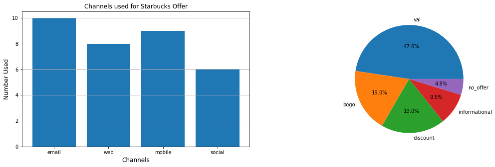

```python
channels = ['email', 'web', 'mobile', 'social']
offer_type = ['val', 'bogo', 'discount', 'informational', 'no_offer']
fig, ax = plt.subplots(1, 2, figsize=(18,5))
# plot a bar chart on channels
ax[0].grid(which='major', axis='y')
ax[0].set_title('Channels used for Starbucks Offer')
ax[0].set_xlabel('Channels', fontsize=12)
ax[0].set_ylabel('Number Used', fontsize=12)
ax[0].bar(channels, portfolio[channels].sum());

#plot a pie plot on offers
ax[1].pie(portfolio[offer_type].sum(), labels = offer_type, autopct='%1.1f%%')
```

The most preferred method for sending promotion is through *email*, then through *mobile*. And the most preferred type of offer is through *value back*.

### Profile Dataset Understanding

The profile has 17000 rows and 5 columns, meaning it contains data of 17000 individuals.

```python
profile.shape
```

```
(17000, 5)
```

```python
profile.head()
```

|  | gender | age | id | became_member_on | income |
| --- | --- | --- | --- | --- | --- |
| 0 | None | 118 | 68be06ca386d4c31939f3a4f0e3dd783 | 20170212 | NaN |
| 1 | F | 55 | 0610b486422d4921ae7d2bf64640c50b | 20170715 | 112000.0 |
| 2 | None | 118 | 38fe809add3b4fcf9315a9694bb96ff5 | 20180712 | NaN |
| 3 | F | 75 | 78afa995795e4d85b5d9ceeca43f5fef | 20170509 | 100000.0 |
| 4 | None | 118 | a03223e636434f42ac4c3df47e8bac43 | 20170804 | NaN |

Take a look at the entries in the profile data.

```python
profile.describe()
```

|  | age | became_member_on | income |
| --- | --- | --- | --- |
| count | 17000.000000 | 1.700000e+04 | 14825.000000 |
| mean | 62.531412 | 2.016703e+07 | 65404.991568 |
| std | 26.738580 | 1.167750e+04 | 21598.299410 |
| min | 18.000000 | 2.013073e+07 | 30000.000000 |
| 25% | 45.000000 | 2.016053e+07 | 49000.000000 |
| 50% | 58.000000 | 2.017080e+07 | 64000.000000 |
| 75% | 73.000000 | 2.017123e+07 | 80000.000000 |
| max | 118.000000 | 2.018073e+07 | 120000.000000 |

The age description is not accurate because people who did not input age are considered age 118. So we need to apply some data cleaning.

The `profile_clean` function performs the following actions:

1. change the age 118 to the median age of the rest of the group
2. fill the non-filled salary with average salary
3. One hot encoding to separate gender into 4 different categories
4. Update the became_member_on column from an integer of yearmonthdate to an integer of days from today.
5. set column 'id' as index

```python
profile_cleaned = starbucks.profile_clean(profile = profile)
```

```
number of users with no age entry: 2175
number of users without salary entry: 2175
percentage of users without salary entry: 12.794117647058824 %
```

```python
profile_cleaned.head()
```

| id | age | income | gender_F | gender_M | gender_O | gender_nan | membership_days |
| --- | --- | --- | --- | --- | --- | --- | --- |
| 68be06ca386d4c31939f3a4f0e3dd783 | 55.0 | 65404.991568 | 0 | 0 | 0 | 1 | 1232 |
| 0610b486422d4921ae7d2bf64640c50b | 55.0 | 112000.000000 | 1 | 0 | 0 | 0 | 1079 |
| 38fe809add3b4fcf9315a9694bb96ff5 | 55.0 | 65404.991568 | 0 | 0 | 0 | 1 | 717 |
| 78afa995795e4d85b5d9ceeca43f5fef | 75.0 | 100000.000000 | 1 | 0 | 0 | 0 | 1146 |
| a03223e636434f42ac4c3df47e8bac43 | 55.0 | 65404.991568 | 0 | 0 | 0 | 1 | 1059 |

```python
#extract membership dates
member_date = profile.became_member_on.apply(lambda x: x//10000)
```

```
 [Text(0.4032354339390165, 1.023426199008025, '2017'),
 [Text(0.2199466003303726, 0.5582324721861953, '38.1%'),
```

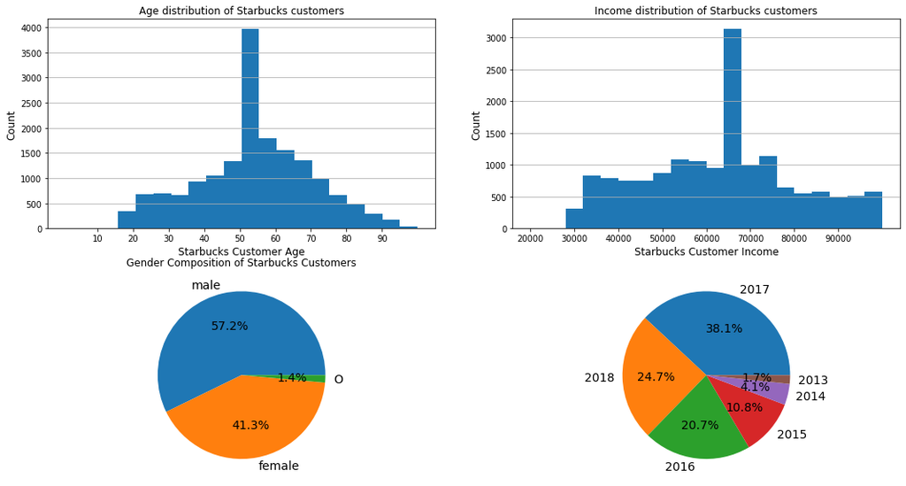

```python
# take a look at age and income distribution.
fig, ax = plt.subplots(2, 2, figsize=(18,10))
ax[0, 0].set_xticks(np.arange(10,100,10));
ax[0, 0].grid(which='major', axis='y')
ax[0, 0].set_title('Age distribution of Starbucks customers')
ax[0, 0].set_xlabel('Starbucks Customer Age', fontsize=12)
ax[0, 0].set_ylabel('Count', fontsize=12)
ax[0, 0].hist(profile.age, bins=20, range=(1,100));

# Take a look at the income distribution
ax[0, 1].set_xticks(np.arange(20000,100000,10000));
ax[0, 1].grid(which='major', axis='y')
ax[0, 1].set_title('Income distribution of Starbucks customers')
ax[0, 1].set_xlabel('Starbucks Customer Income', fontsize=12)
ax[0, 1].set_ylabel('Count', fontsize=12)

ax[0, 1].hist(profile.income, bins=20, range=(20000,100000));

#Check out the gender distribution of the users
ax[1, 0].pie(profile.gender.value_counts(), labels = ['male', 'female', 'O'], autopct='%1.1f%%', textprops={'fontsize': 14})
ax[1, 0].set_title('Gender Composition of Starbucks Customers')

#Check out the memebership years of the members
ax[1, 1].pie(member_date.value_counts(), labels = member_date.value_counts().index, autopct='%1.1f%%', textprops={'fontsize': 14})
```

Among the 17000 members,

- the distribution of ago peaks at 50 - 60, with a left shoulder at 23-30 years.
- The salary is more evenly distributed with a range from \$30, 000/year to more than \$100,000/year, meaning Starbucks is loved by customers regardless of income.
- There are ~16% more male members than female members.
- Most of the customers joined at the year of 2017.

```python
print(f'''There are total of {profile.shape[0]} people,
{profile.gender.isna().sum()} of those did not put in their gender,
{profile.groupby('gender').count().loc['F','age']} of them are females,
{profile.groupby('gender').count().loc['M','age']} of them are males,
{profile.groupby('gender').count().loc['O','age']} are gender O.
Those who did not put their gender will be considered another category N.
''')
```

```
There are total of 17000 people,
2175 of those did not put in their gender,
6129 of them are females,
8484 of them are males,
212 are gender O.
Those who did not put their gender will be considered another category N.
```

### Transcript Dataset Exploration and Visualization

```python
print(f'''Let's gain some understanding of the transcript data:
the number of entries in the dataset is: {transcript.shape[0]},
the number of customers in the transcript is: {transcript.person.nunique()},
there are 4 types of events recorded: {transcript.event.unique()}
{transcript[transcript['event'] == 'offer received'].shape[0]} are offer received,
{transcript[transcript['event'] == 'offer viewed'].shape[0]} are offer viewed,
{transcript[transcript['event'] == 'transaction'].shape[0]} are transactions,
{transcript[transcript['event'] == 'offer completed'].shape[0]} are offer completed.
''')
```

```
Let's gain some understanding of the transcript data:
the number of entries in the dataset is: 306534,
the number of customers in the transcript is: 17000,
there are 4 types of events recorded: ['offer received' 'offer viewed' 'transaction' 'offer completed']
76277 are offer received,
57725 are offer viewed,
138953 are transactions,
33579 are offer completed.
```

Transactions has the highest number among all events. There are multiple possibilities among the data:

1. The person **receives** the offer
   - The person viewed the offer
     - The person made the purchase
     - The person does not make the purchase
   - The person did not see the offer
     - The person made the purchase
     - The person does not make the purchase
2. The person **did not receive** the offer
   - The person made the purchase regardless

```python
transcript = pd.read_json('data/transcript.json', orient='records', lines=True)
```

```python
transcript_transformed = starbucks.transcript_clean(transcript = transcript,  portfolio = portfolio)
```

```
Transforming transcript
Assigning offer received, offer viewed and offer completed values...
Assigning transaction count...
Working on transaction value now...
```

```
[                                                                        ]   0%
```

```
Extracting transaction value
```

```
performing final dataframe cleaning...
```

The transformed transcript has 6 columns: 2 on ids, and 4 on data. 4 data columns are: offer_received, offer_viewed, transaction, and transaction_amt. Each column should be looked at individually. Thus I will pivot the Dataframe with person ids for rows, offer ids for columns.

```python
# generate dataframe demonstrating the transition amount per person per offer.
trans_amt = pd.pivot_table(transcript_transformed, values = 'transaction_amt', index = ['person'], columns = ['offer'])
trans_amt.head()
```

| offer person | 0b1e1539f2cc45b7b9fa7c272da2e1d7 | 2298d6c36e964ae4a3e7e9706d1fb8c2 | 2906b810c7d4411798c6938adc9daaa5 | 3f207df678b143eea3cee63160fa8bed | 4d5c57ea9a6940dd891ad53e9dbe8da0 | 5a8bc65990b245e5a138643cd4eb9837 | 9b98b8c7a33c4b65b9aebfe6a799e6d9 | ae264e3637204a6fb9bb56bc8210ddfd | f19421c1d4aa40978ebb69ca19b0e20d | fafdcd668e3743c1bb461111dcafc2a4 | wo_offer |
| --- | --- | --- | --- | --- | --- | --- | --- | --- | --- | --- | --- |
| 0009655768c64bdeb2e877511632db8f | 0.00 | 0.00 | 46.51 | 0.0 | 0.00 | 0.0 | 0.00 | 0.0 | 8.57 | 22.68 | 49.84 |
| 00116118485d4dfda04fdbaba9a87b5c | 0.00 | 0.00 | 0.00 | 0.0 | 0.00 | 0.0 | 0.00 | 0.0 | 0.00 | 0.00 | 0.00 |
| 0011e0d4e6b944f998e987f904e8c1e5 | 22.05 | 25.42 | 0.00 | 0.0 | 0.00 | 0.0 | 22.05 | 0.0 | 0.00 | 0.00 | 9.94 |
| 0020c2b971eb4e9188eac86d93036a77 | 0.00 | 0.00 | 0.00 | 0.0 | 17.24 | 0.0 | 0.00 | 0.0 | 0.00 | 34.87 | 144.75 |
| 0020ccbbb6d84e358d3414a3ff76cffd | 0.00 | 11.65 | 0.00 | 0.0 | 0.00 | 0.0 | 40.18 | 0.0 | 35.61 | 0.00 | 66.61 |

```python
def autolabel(rects, ax = ax):
    """Attach a text label above each bar in *rects*, displaying its height."""
    for rect in rects:
        height = rect.get_height()
        ax.annotate('{}'.format(round(height, 0)),
                    xy=(rect.get_x() + rect.get_width() / 2, height),
                    xytext=(0, 3),  # 3 points vertical offset
                    textcoords="offset points",
                    ha='center', va='bottom')
```

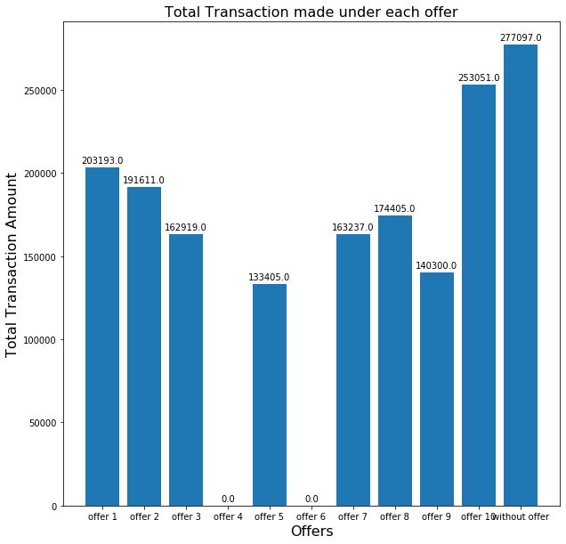

```python
labels = ['offer 1', 'offer 2', 'offer 3', 'offer 4', 'offer 5', 'offer 6', 'offer 7', 'offer 8', 'offer 9', 'offer 10', 'without offer']
transation_amt = []
for col in trans_amt.columns:
    transation_amt.append(trans_amt[col].sum())
fig, ax = plt.subplots(figsize = (10, 10))
rects1 = ax.bar(x = range(11), height = transation_amt, tick_label = labels);
ax.set_xlabel('Offers', fontsize = 16);
ax.set_ylabel('Total Transaction Amount', fontsize = 16);
ax.set_title('Total Transaction made under each offer', fontsize = 16)
autolabel(rects1, ax = ax)
plt.show()
```

There are a lot of attributes associated with each offer. Now we need to put those attributes into consideration, by taking the dot product of user-offer matrix and offer-attribute matrix.

```python
#the dot product of user-offer matrix and offer-attribute matrix.
user_port_matx = trans_amt.dot(portfolio)
user_port_matx.head()
```

| person | reward | difficulty | duration | social | email | mobile | web | val | bogo | discount | informational | no_offer |
| --- | --- | --- | --- | --- | --- | --- | --- | --- | --- | --- | --- | --- |
| 0009655768c64bdeb2e877511632db8f | 181.23 | 734.75 | 595.22 | 31.25 | 77.76 | 77.76 | 77.76 | 77.76 | 8.57 | 69.19 | 0.0 | 49.84 |
| 00116118485d4dfda04fdbaba9a87b5c | 0.00 | 0.00 | 0.00 | 0.00 | 0.00 | 0.00 | 0.00 | 0.00 | 0.00 | 0.00 | 0.0 | 0.00 |
| 0011e0d4e6b944f998e987f904e8c1e5 | 296.76 | 729.19 | 552.79 | 25.42 | 69.52 | 47.47 | 69.52 | 69.52 | 22.05 | 47.47 | 0.0 | 9.94 |
| 0020c2b971eb4e9188eac86d93036a77 | 242.14 | 521.10 | 434.90 | 52.11 | 52.11 | 52.11 | 52.11 | 52.11 | 17.24 | 34.87 | 0.0 | 144.75 |
| 0020ccbbb6d84e358d3414a3ff76cffd | 413.90 | 460.50 | 540.86 | 47.26 | 87.44 | 87.44 | 87.44 | 87.44 | 75.79 | 11.65 | 0.0 | 66.61 |

Take a look at how transaction amount is associated with each attribute .

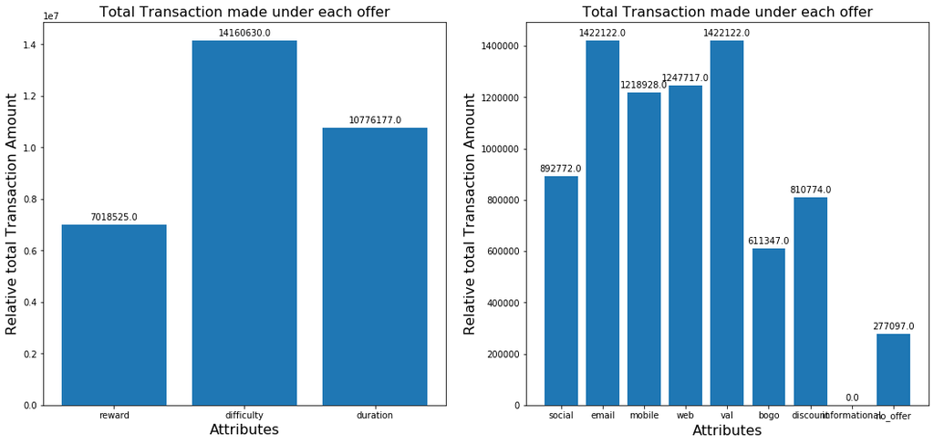

```python
labels = user_port_matx.columns
labels1 = labels[:3]
labels2 = labels[3:]

transation_amt = []
for col in user_port_matx.columns:
    transation_amt.append(user_port_matx[col].sum())

fig, ax = plt.subplots(1, 2,figsize = (18, 8))

rects1 = ax[0].bar(x = range(len(labels1)), height = transation_amt[:3], tick_label = labels1);
ax[0].set_xlabel('Attributes', fontsize = 16);
ax[0].set_ylabel('Relative total Transaction Amount', fontsize = 16);
ax[0].set_title('Total Transaction made under each offer', fontsize = 16)
autolabel(rects1, ax = ax[0])

rects2 = ax[1].bar(x = range(len(labels2)), height = transation_amt[3:], tick_label = labels2);
ax[1].set_xlabel('Attributes', fontsize = 16);
ax[1].set_ylabel('Relative total Transaction Amount', fontsize = 16);
ax[1].set_title('Total Transaction made under each offer', fontsize = 16)
autolabel(rects2, ax = ax[1])
plt.show()
```

The figure on the left does not have much statistical significance because the rewards, difficulty and durations are numbers on different scales. So they are not comparible. However, they will be helpful later in clustering the customers.

The plot on the right is very interesting. The previous plot seems to show that more transaction is made without any offer. This is the opposite from the graph above. Seems like in total, people prefer to spend with an offer than without. **Email** sent offers generates the most transaction. And the **value type** discount are customers' favorite discount.

Now we add customer demographic to see if there is any trend.

```python
trans_amt_master = user_port_matx.merge(profile_cleaned, how = 'inner',\
                                       left_index = True, right_index = True, validate = 'one_to_one')
```

```python
portfolios_lst = user_port_matx.columns
profiles_lst = profile.columns
```

```python
trans_amt_master.head()
```

|  | reward | difficulty | duration | social | email | mobile | web | val | bogo | discount | informational | no_offer | age | income | gender_F | gender_M | gender_O | gender_nan | membership_days |
| --- | --- | --- | --- | --- | --- | --- | --- | --- | --- | --- | --- | --- | --- | --- | --- | --- | --- | --- | --- |
| 0009655768c64bdeb2e877511632db8f | 181.23 | 734.75 | 595.22 | 31.25 | 77.76 | 77.76 | 77.76 | 77.76 | 8.57 | 69.19 | 0.0 | 49.84 | 33.0 | 72000.000000 | 0 | 1 | 0 | 0 | 1164 |
| 00116118485d4dfda04fdbaba9a87b5c | 0.00 | 0.00 | 0.00 | 0.00 | 0.00 | 0.00 | 0.00 | 0.00 | 0.00 | 0.00 | 0.0 | 0.00 | 55.0 | 65404.991568 | 0 | 0 | 0 | 1 | 795 |
| 0011e0d4e6b944f998e987f904e8c1e5 | 296.76 | 729.19 | 552.79 | 25.42 | 69.52 | 47.47 | 69.52 | 69.52 | 22.05 | 47.47 | 0.0 | 9.94 | 40.0 | 57000.000000 | 0 | 0 | 1 | 0 | 901 |
| 0020c2b971eb4e9188eac86d93036a77 | 242.14 | 521.10 | 434.90 | 52.11 | 52.11 | 52.11 | 52.11 | 52.11 | 17.24 | 34.87 | 0.0 | 144.75 | 59.0 | 90000.000000 | 1 | 0 | 0 | 0 | 1577 |
| 0020ccbbb6d84e358d3414a3ff76cffd | 413.90 | 460.50 | 540.86 | 47.26 | 87.44 | 87.44 | 87.44 | 87.44 | 75.79 | 11.65 | 0.0 | 66.61 | 24.0 | 60000.000000 | 1 | 0 | 0 | 0 | 1325 |

Take a look at spending habit difference between males and females.

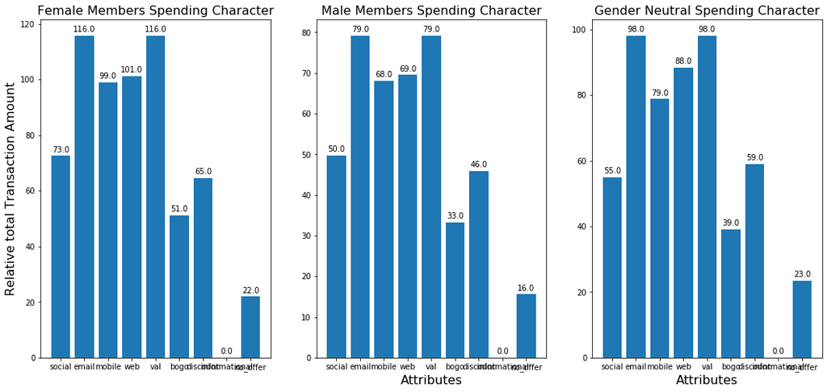

```python
trans_amt_female  = trans_amt_master[trans_amt_master.gender_F == 1][labels2].mean()
trans_amt_male  = trans_amt_master[trans_amt_master.gender_M == 1][labels2].mean()
trans_amt_neutral  = trans_amt_master[trans_amt_master.gender_O == 1][labels2].mean()
fig, ax = plt.subplots(1, 3,figsize = (18, 8))

rects1 = ax[0].bar(x = list(trans_amt_female.index), height = list(trans_amt_female));
ax[0].set_ylabel('Relative total Transaction Amount', fontsize = 16);
ax[0].set_title('Female Members Spending Character', fontsize = 16)
autolabel(rects1, ax = ax[0])

rects2 = ax[1].bar(x = trans_amt_male.index, height = trans_amt_male, tick_label = labels2);
ax[1].set_xlabel('Attributes', fontsize = 16);
ax[1].set_title('Male Members Spending Character', fontsize = 16)
autolabel(rects2, ax = ax[1])

rects2 = ax[2].bar(x = trans_amt_neutral.index, height = trans_amt_neutral, tick_label = labels2);
ax[2].set_xlabel('Attributes', fontsize = 16);
ax[2].set_title('Gender Neutral Spending Character', fontsize = 16)
autolabel(rects2, ax = ax[2])

plt.show()
```

Female, male or neutral gender besically have the same spending behavior.

#### Spending Behavior by Salary

```python
labels
```

```
Index(['reward', 'difficulty', 'duration', 'social', 'email', 'mobile', 'web',
       'val', 'bogo', 'discount', 'informational', 'no_offer'],
      dtype='object')
```

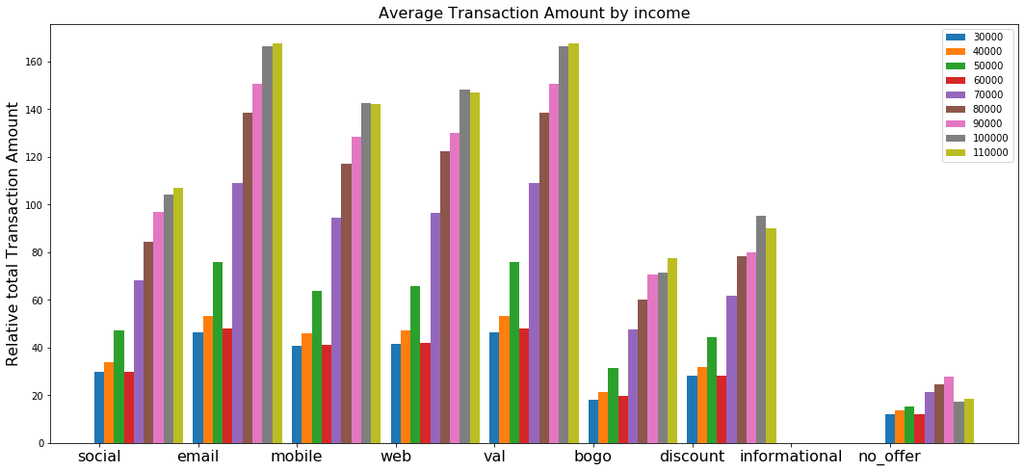

```python
starbucks.plot_demo_attribute(demographic = 'income', labels = labels2, lower_limit = 30000, higher_limit = 130000, step = 10000, trans_amt_master = trans_amt_master)
```

According to the graph above, we can see that the spending amount between different salary groups are different. Those with salary of less that 70k spends less than 100 dollars per month. Those with salary higher than 70k spends significantly more of more than 100 dollars per month. However, regardless of salary, people's preference over the offers are pretty similar.

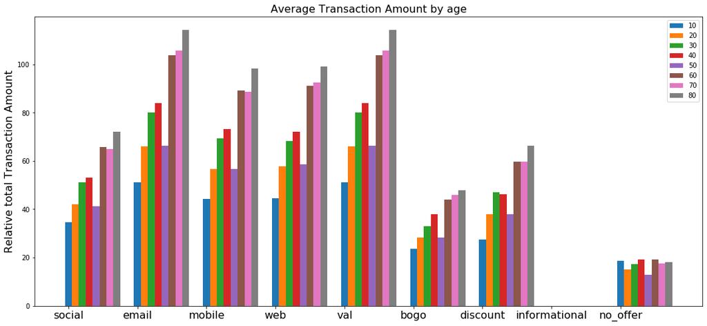

```python
starbucks.plot_demo_attribute(demographic = 'age', labels = labels2, lower_limit = 10, higher_limit = 100, step = 10, trans_amt_master = trans_amt_master)
```

Looking at transaction distributions among different age groups we see older people spend more than the younger people. However, this is not the case when there is no offer. This probably indicates the older generation is more wise with money and will not spend unless there is an offer. However, again the distribution among different offer atributes of each age group do not have high variability.

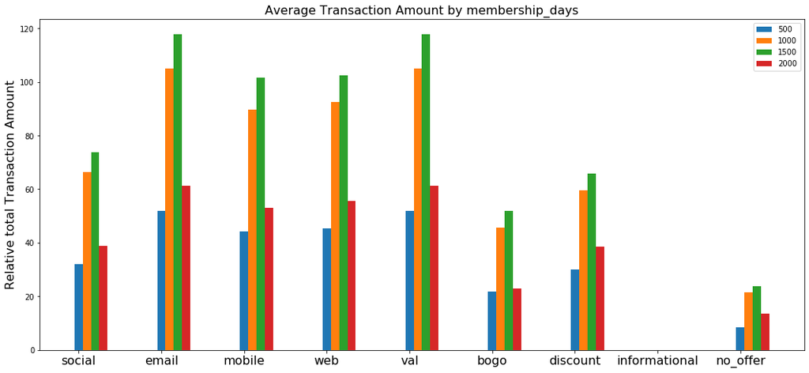

```python
starbucks.plot_demo_attribute(demographic = 'membership_days', labels = labels2, lower_limit = 500, higher_limit = 3000, step = 500, trans_amt_master = trans_amt_master)
```

**In conclusion, there does not seem to be a significant difference among different demographic characters across offer attributes.** This might indicate, it can be difficult to predict an individual's preference based on his/her demographic characters. We will now check it out with machine learning.

## Methodology

### Clustering

Here I will use **Standard Scaler** to preprocess the data.

```python
from sklearn.cluster import DBSCAN
import sklearn.utils
from sklearn.neighbors import NearestNeighbors
from sklearn.preprocessing import StandardScaler
import seaborn as sns

from matplotlib.ticker import StrMethodFormatter
#Visualise Clustering with TSNE
from sklearn.manifold import TSNE
```

```python
trans_amt_master_fitted = StandardScaler().fit_transform(trans_amt_master)
```

##### First, we try the dataset cntaining both the offer attributes and memer demographic characters

Trying to find the optimal epsilon and sample size for clustering.

We find a suitable value for epsilon by calculating the distance to the nearest 10 points for each point, sorting and plotting the results. Then we look to see where the change is most pronounced and select that as epsilon.

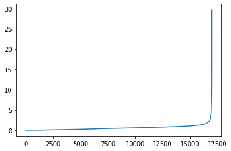

```python
starbucks.plot_dist_distribution(data = trans_amt_master, n_neighbors=10)
```

Here we can guess epsilon is somewhere between **0.5 to 2**, since it is where the turning point is.

Plot a heatmap showing how the number of clusters and number of un-clustered samples with different epsilon and sample size values.

```
[========================================================================] 100%
```

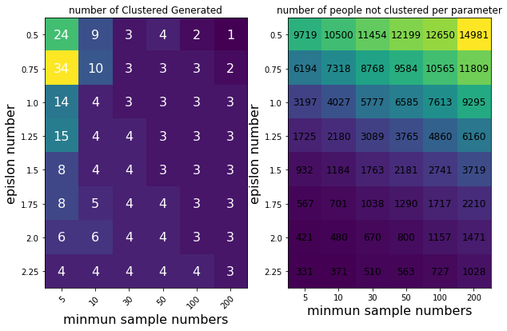

```python
sample_sizes = [5, 10, 30, 50, 100, 200]
starbucks.cluster_by_epi_size(0.5, 2.5, 0.25, sample_sizes = sample_sizes, data = trans_amt_master)
```

I will select **epsilon = 2.25 , min_sample_size = 10** for my future study.

```python
cluster_labels, clusterNum, realClusterNum = starbucks.density_based_clustering(trans_amt_master, eps = 2.25, min_samples = 10)
realClusterNum
```

```
4
```

```
 [Text(2.1948314077610847, 0.15071526633190382, '-1'),
 [Text(1.1971807678696824, 0.08220832709012936, '2.2%'),
```

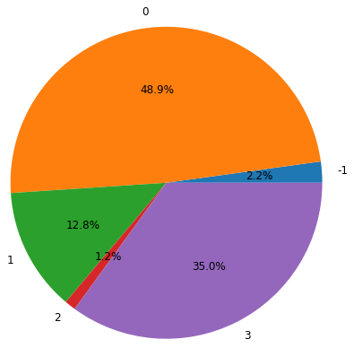

```python
trans_amt_master_clustered = trans_amt_master.copy()
trans_amt_master_clustered['clusters'] = cluster_labels
cluster_count = trans_amt_master_clustered.groupby('clusters').count().iloc[: , 1]
plt.pie(cluster_count, labels = np.arange(-1, clusterNum-1), autopct='%1.1f%%', textprops={'fontsize': 12}, radius = 2)
```

```
generating data...
plotting data...
```

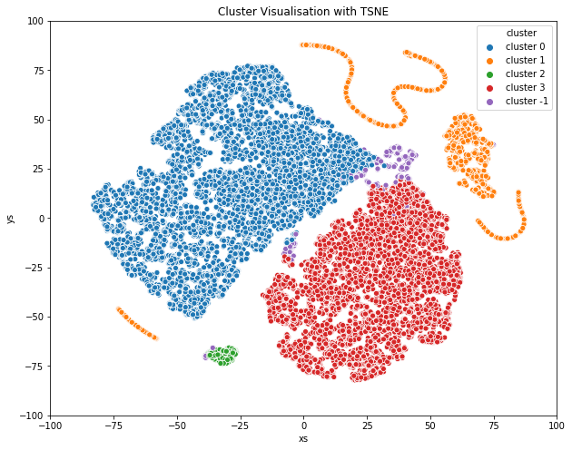

```python
starbucks.plot_cluster(data = trans_amt_master, labels = cluster_labels)
```

```python
trans_amt_master_clustered.groupby('clusters').mean()
```

| clusters | reward | difficulty | duration | social | email | mobile | web | val | bogo | discount | informational | no_offer | age | income | gender_F | gender_M | gender_O | gender_nan | membership_days |
| --- | --- | --- | --- | --- | --- | --- | --- | --- | --- | --- | --- | --- | --- | --- | --- | --- | --- | --- | --- |
| -1 | 3405.586226 | 6694.196631 | 4996.059623 | 423.400270 | 659.481375 | 560.081429 | 563.475849 | 659.481375 | 298.145930 | 361.335445 | 0.0 | -9.916469 | 55.924528 | 74269.029604 | 0.477089 | 0.474394 | 0.043127 | 0.005391 | 1310.805930 |
| 0 | 319.915412 | 655.608346 | 502.772943 | 41.594154 | 66.198240 | 56.976745 | 58.563299 | 66.198240 | 27.687703 | 38.510537 | 0.0 | 16.607416 | 52.076914 | 60987.000481 | 0.000000 | 1.000000 | 0.000000 | 0.000000 | 1231.662735 |
| 1 | 33.847161 | 78.015283 | 68.716553 | 6.576498 | 8.892020 | 8.335633 | 8.432642 | 8.892020 | 2.839015 | 6.053005 | 0.0 | 2.625246 | 55.000000 | 65404.991568 | 0.000000 | 0.000000 | 0.000000 | 1.000000 | 1186.044639 |
| 2 | 368.440306 | 722.337653 | 564.764694 | 45.724082 | 74.832959 | 65.011735 | 65.685408 | 74.832959 | 34.532245 | 40.300714 | 0.0 | 25.965765 | 53.846939 | 62336.734694 | 0.000000 | 0.000000 | 1.000000 | 0.000000 | 1175.602041 |
| 3 | 495.872223 | 994.486517 | 753.626808 | 61.638765 | 99.712631 | 85.167981 | 87.520949 | 99.712631 | 43.307831 | 56.404800 | 0.0 | 22.178683 | 57.549899 | 71120.295699 | 1.000000 | 0.000000 | 0.000000 | 0.000000 | 1213.204301 |

```python
offer_labels = labels
demographic_labels = list(profile_cleaned.columns)
```

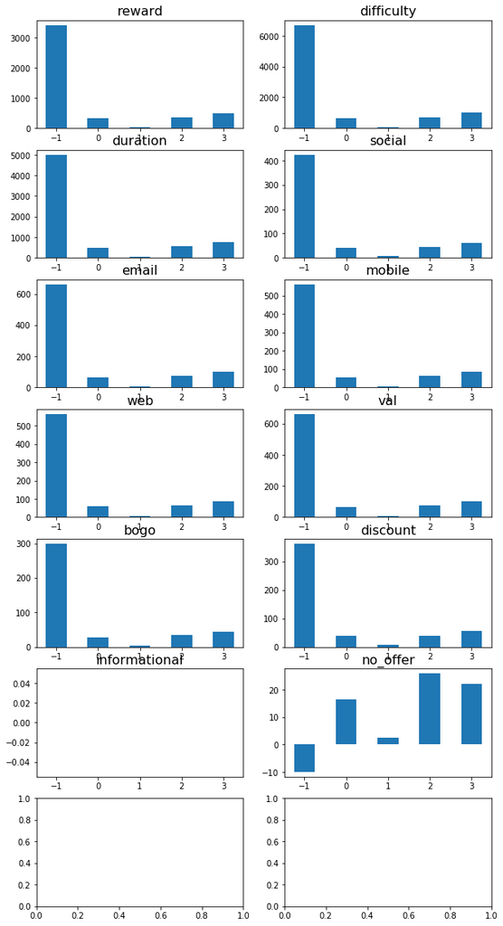

```python
starbucks.plot_cluster_data(data = trans_amt_master, cluster_labels = cluster_labels, labels = offer_labels, all_real = False, clusterNum = clusterNum)
```

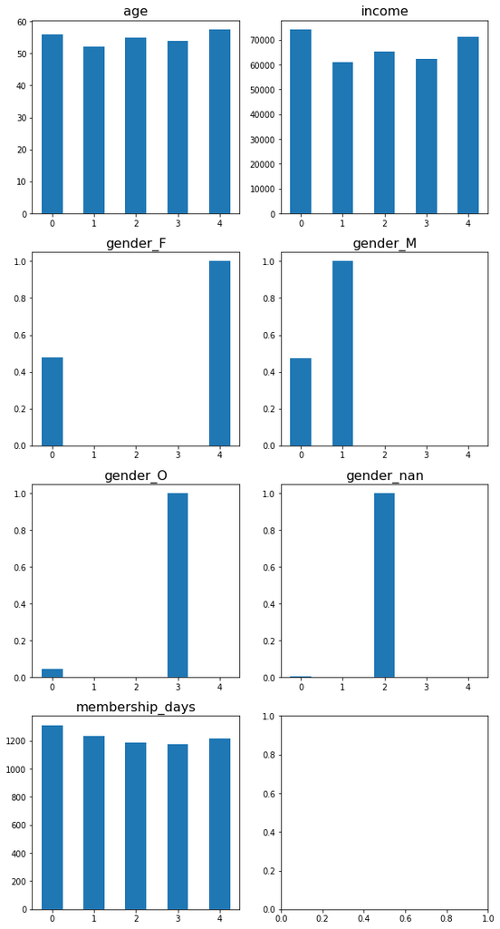

```python
starbucks.plot_cluster_data(data = trans_amt_master, cluster_labels = cluster_labels, labels = demographic_labels, clusterNum = clusterNum, all_real = False)
```

#### Discussion

This method of density based clustering seems to be more biased towards the demongraphic features.

[output not shown]

### Clustering with user-por-matrix

**Here we disregard user character and just cluster based on their buying behavior.**

```python
user_port_matx_fitted = StandardScaler().fit_transform(user_port_matx)
```

Trying to find the optimal epsilon and sample size for clustering.

We find a suitable value for epsilon by calculating the distance to the nearest 10 points for each point, sorting and plotting the results. Then we look to see where the change is most pronounced and select that as epsilon.

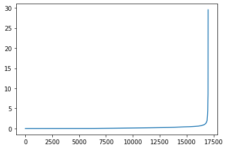

```python
starbucks.plot_dist_distribution(data = user_port_matx, n_neighbors=10)
```

A very flat bottom of the distance curve means the distance variance between the points are very small.

Here we can guess epsilon is somewhere between **0.2 to 0.8**, since it is where the turning point is.

Plot a heatmap showing how the number of clusters and number of un-clustered samples with different epsilon and sample size values.

```
[========================================================================] 100%
```

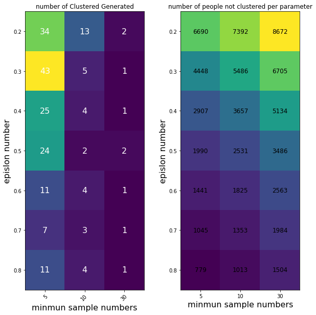

```python
sample_sizes = [5, 10, 30]
starbucks.cluster_by_epi_size(0.2, 0.8, 0.1, sample_sizes = sample_sizes, data = user_port_matx)
```

I will select **epsilon = 0.6 , min_sample_size = 20** for my future study.

```python
cluster_labels, clusterNum, realClusterNum = starbucks.density_based_clustering(user_port_matx, eps = 0.6, min_samples = 20)
realClusterNum
```

```
1
```

```
 [Text(2.0024015662071566, 0.9112562579489524, '-1'),
 [Text(1.0922190361129942, 0.4970488679721558, '13.6%'),
```

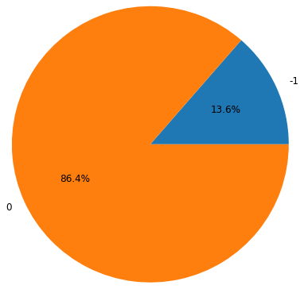

```python
user_port_matx_clustered = user_port_matx.copy()
user_port_matx_clustered['clusters'] = cluster_labels
cluster_count = user_port_matx_clustered.groupby('clusters').count().iloc[: , 1]
plt.pie(cluster_count, labels = np.arange(-1, clusterNum-1), autopct='%1.1f%%', textprops={'fontsize': 12}, radius = 2)
```

##### Density Based Clustering Conclusion:

From density based clustering, I only got **one** real cluster. It seems like it is very difficult to distinguish the clusters using the density-based clustering. This is likely due to the tightly clustered data and the distance between the data points are too homogeneous to be distinguished.

If we look at the distance distribution plot, an almost flat bottom indicates that the the distance variance between the data is very very small, thus making clusting difficult.

I will quickly try out 2 other clustering method to see if they will work or not.

#### Agglomerative Clustering

```
 [Text(2.1995118107116878, 0.04634430428643699, '0'),
 [Text(1.1997337149336478, 0.025278711428965626, '0.7%'),
```

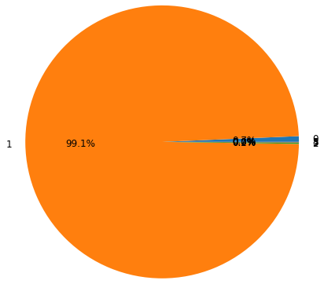

```python
from sklearn.cluster import AgglomerativeClustering
user_port_matx_fitted = StandardScaler().fit_transform(user_port_matx)
agglom = AgglomerativeClustering(n_clusters = 6, linkage = 'complete')
agglom.fit(user_port_matx_fitted)
agglom_cluster_labels = agglom.labels_


agglom_clusterNum = len(set(agglom_cluster_labels))

user_port_matx_agglom = user_port_matx.copy()
user_port_matx_agglom['clusters'] = agglom_cluster_labels
agglom_cluster_count = user_port_matx_agglom.groupby('clusters').count().iloc[: , 1]
plt.pie(agglom_cluster_count, labels = np.arange(0, agglom_clusterNum), autopct='%1.1f%%', textprops={'fontsize': 12}, radius = 2)
```

Again, agglomerative clustering clustered almost all data together. Possibly due to the same issue I have mentioned earlier.

#### K-means Clustering

```python
from sklearn.cluster import KMeans
clusterNum = 5
k_means = KMeans(init = "k-means++", n_clusters = clusterNum, n_init = 12)
k_means.fit(user_port_matx_fitted)
km_cluster_labels = k_means.labels_
km_clusterNum = len(set(km_cluster_labels))
```

```
 [Text(1.430639736486179, 1.6713078544621147, '-1'),
 [Text(0.7803489471742793, 0.9116224660702443, '27.5%'),
```

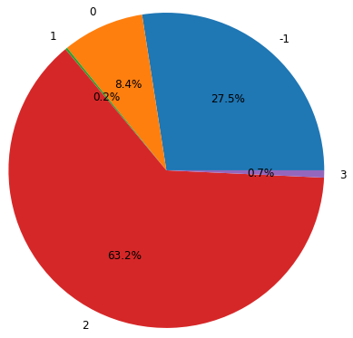

```python
user_port_matx_km = user_port_matx.copy()
user_port_matx_km['clusters'] = km_cluster_labels
cluster_count = user_port_matx_km.groupby('clusters').count().iloc[: , 1]
plt.pie(cluster_count, labels = np.arange(-1, clusterNum-1), autopct='%1.1f%%', textprops={'fontsize': 12}, radius = 2)
```

```
generating data...
plotting data...
```

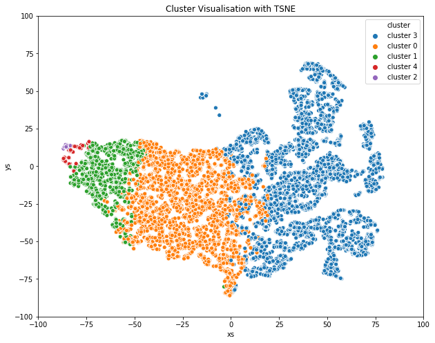

```python
starbucks.plot_cluster(data = user_port_matx, labels = km_cluster_labels)
```

The k-means clustering seems to be doing better. Let's take a look at the data to see if it is really true or not.

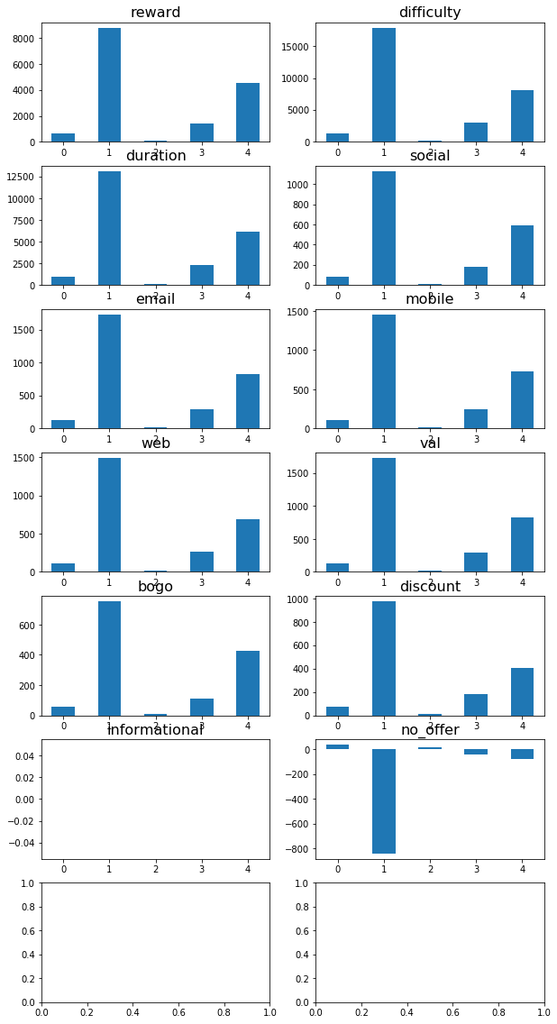

```python
starbucks.plot_cluster_data(data = user_port_matx, cluster_labels = km_cluster_labels, labels = offer_labels, clusterNum = km_clusterNum, all_real = True)
```

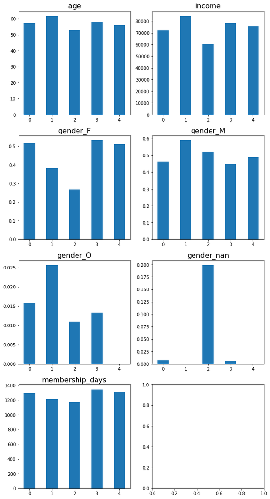

```python
starbucks.plot_cluster_data(data = trans_amt_master, cluster_labels = km_cluster_labels, clusterNum = km_clusterNum, labels = demographic_labels)
```

## Machine Learning

Since clustering method isn't very accurate and straight-forward, regression will be used to tell if there is a correlation between demographics and transaction from different offer attributes. The expectation is that it will not be too accurate, because:

1. plots in data exploration shows little variation among different demographic groups

```python
from sklearn.multioutput import MultiOutputRegressor
from sklearn.model_selection import train_test_split
from sklearn.neighbors import KNeighborsRegressor
from sklearn.ensemble import ExtraTreesRegressor
from sklearn.metrics import mean_squared_error, r2_score, accuracy_score, f1_score
```

Set the X and Y data. **X** the independent variable will be customer's demongraphic information.

The **Y** data will be the relative transaction amount under different offer attributes

```python
X = trans_amt_master[demographic_labels]
Y = trans_amt_master[offer_labels]
```

```python
X_train, X_test, Y_train, Y_test = train_test_split(X, Y, test_size=0.3, random_state=42)
```

### 1. k_nearest neighbors regression

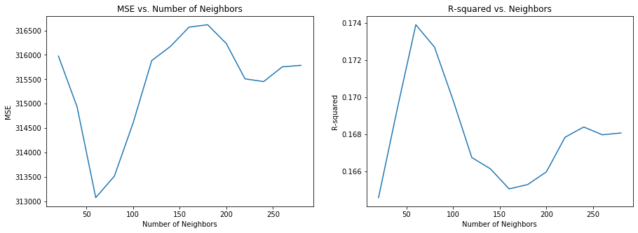

```python
num_neighbors = np.arange(20,300,20)
MSE_lst = []
R2_lst = []

for n in num_neighbors:
    knn = KNeighborsRegressor(n, weights='uniform')
    knn_model = knn.fit(X_train, Y_train)
    Y_pred = knn_model.predict(X_test)
    MSE = mean_squared_error(Y_test, Y_pred)
    R2 = r2_score(Y_test, Y_pred)
    MSE_lst.append(MSE)
    R2_lst.append(R2)

fig, ax = plt.subplots(1, 2, figsize = (15, 5))
ax[0].plot(num_neighbors, MSE_lst);
ax[0].set_xlabel('Number of Neighbors');
ax[0].set_ylabel('MSE');
ax[0].set_title('MSE vs. Number of Neighbors');

ax[1].plot(num_neighbors, R2_lst);
ax[1].set_xlabel('Number of Neighbors');
ax[1].set_ylabel('R-squared');
ax[1].set_title('R-squared vs. Neighbors');
```

```python
print(f'''the lowest MSE achieved with k_nearest neighbors regression is {round(min(MSE_lst))},
the highest R-squared achieved with k-nearest neighbors regressions is {round(max(R2_lst), 2)},
the number of neighbors used for the best model is 60.''')
```

```
the lowest MSE achieved with k_nearest neighbors regression is 313076.0,
the highest R-squared achieved with k-nearest neighbors regressions is 0.17,
the number of neighbors used for the best model is 60.
```

### Extra Tree Regressor

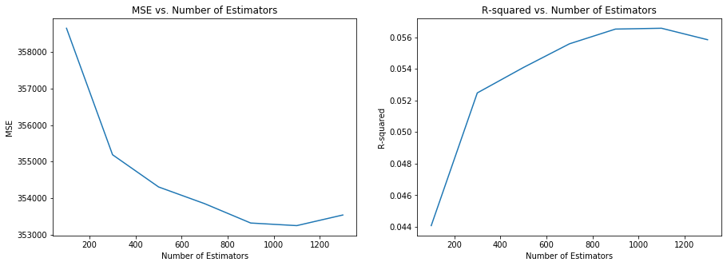

```python
num_estimators = np.arange(100,1500,200)
MSE_lst = []
R2_lst = []

for n in num_estimators:
    extrat = ExtraTreesRegressor(n_estimators=n, max_features='auto',
                                       random_state=0)
    extrat_model = extrat.fit(X_train, Y_train)
    Y_pred_t = extrat.predict(X_test)
    MSE = mean_squared_error(Y_test, Y_pred_t)
    R2 = r2_score(Y_test, Y_pred_t)
    MSE_lst.append(MSE)
    R2_lst.append(R2)

fig, ax = plt.subplots(1, 2, figsize = (15, 5))
ax[0].plot(num_estimators, MSE_lst);
ax[0].set_xlabel('Number of Estimators');
ax[0].set_ylabel('MSE');
ax[0].set_title('MSE vs. Number of Estimators');

ax[1].plot(num_estimators, R2_lst);
ax[1].set_xlabel('Number of Estimators');
ax[1].set_ylabel('R-squared');
ax[1].set_title('R-squared vs. Number of Estimators');
```

```python
print(f'''the lowest MSE achieved with extra tree regression is {round(min(MSE_lst))},
the highest R-squared achieved with extra tree regressions is {round(max(R2_lst), 2)},
the number of neighbors used for the best model is around 1100.''')
```

```
the lowest MSE achieved with extra tree regression is 353244.0,
the highest R-squared achieved with extra tree regressions is 0.06,
the number of neighbors used for the best model is around 1100.
```

# Conclusion and Future work

## Future work:

1. the transaction for each promotion is not calculated accurately. Here I only take the amount of the transaction right before the offer completed time as the transaction amount for that offer. But in real, I need to consider all transactions occured within that offer period as the transaction amount belong to that offer. However, we do not know if the person actually applied the offer during the transaction or not, which makes reansaction amount for each offer challenging.

## Reference

1. DBSCAN Python Example: The Optimal Value For Epsilon